# Análisis de Mercado: Ecuador

TP 2: Análisis Inteligente de Datos

Autor/a

Noelia Mengoni

Fecha de publicación

8 de diciembre de 2024

# Introducción

**Wiener Lab** una empresa argentina líder en la producción y comercialización de reactivos y equipos para diagnóstico de laboratorio, se destaca por su enfoque en América Latina y su alcance global. Su misión es ofrecer soluciones innovadoras y de alta calidad en bioquímica, hematología, inmunología y microbiología.

Su principal valor diferencial radica en la capacidad de transformar datos en ventajas competitivas, lo que les permite optimizar procesos, maximizar el desempeño operativo y fortalecer su posición estratégica en el mercado.

# Objetivo del estudio

El propósito principal es analizar el mercado de productos relacionados con diagnósticos de laboratorio utilizando datos de importación proporcionados por `Mercosur Online`. Este análisis permitirá evaluar el comportamiento del mercado, identificar patrones de demanda y competencia, y tomar decisiones estratégicas sobre precios y posicionamiento de productos.

## Fuente

La fuente principal de información será [MERCOSUR_ONLINE](https://auth.gln.com/identityservice/login?appId=133D7731-7B34-4A89-8005-DECD1979089C&returnUrl=https%3A%2F%2Fwww.myvan.descartes.com%2FWelcome), que proporciona datos clave sobre importaciones, como:

- Países de origen y destino
- Códigos de productos que representan categorías específicas.
- Detalles de importación, incluidos cantidades y valores, entre otros.

Dado que los datos descargados (en formatos Excel) suelen estar desorganizados, será necesario un proceso de limpieza y estructuración.

## Alcance

Con los datos organizados, se realizará un análisis exploratorio para generar estadísticas descriptivas y visualizaciones que identifiquen relaciones clave entre las variables. Este paso es crucial para:

- Detectar tendencias y patrones en el mercado.
- Entender las interrelaciones entre las variables.

El análisis exploratorio constituye la fase inicial del proceso, proporcionando una visión global de los datos. A continuación, se avanzará al análisis ad hoc, donde se abordarán consultas específicas derivadas de este análisis, con el fin de obtener respuestas detalladas que guíen las decisiones estratégicas.

# Procesamiento de Datos

## Bibliotecas

En este análisis se utilizan diversas librerías de R que facilitan la manipulación, procesamiento y visualización de los datos. A continuación, se detallan las principales librerías utilizadas: `readxl`, `readr`, `haven`, `dplyr`,`fs`,`stringr`, `purrr`, `here`,`skimr`, `knitr`,`ggplot2`, `kableExtra`, `tidyr`, `tools`, `tibble`, `lubridate`, `scales` y `ggrepel`.

**Código**

```r
# Lista de librerías a utilizar
librerias <- c("readxl", "readr", "haven", "dplyr", "fs","stringr", "purrr", "here", "skimr", "knitr", "ggplot2", "kableExtra", "tidyr", "tools", "tibble", "lubridate", "scales", "ggrepel")
instalar <- librerias[!(librerias %in% installed.packages()[,"Package"])]
if(length(instalar)) install.packages(instalar)
invisible(lapply(librerias, library, character.only = TRUE))
```

## Directorio de trabajo

El primer paso en este análisis consiste en cargar y consolidar todos los archivos descargados desde `Mercosur Online`.

Estos archivos se encuentran almacenados en la carpeta **MERCOSUR_ONLINE**, previamente configurada como el directorio de trabajo.

**¡Atención!** *Es importante tener en cuenta que los archivos se descargan en lotes de hasta 5000 registros (filas), lo que resulta en la generación de múltiples archivos. Esto puede ocasionar que el procesamiento sea más lento debido al volumen de datos.*

## Validación de Archivos

Se procede a verificar la cantidad de archivos presentes en la carpeta, así como las extensiones correspondientes a cada uno de ellos.

**Código**

```r
# Definir la ruta de la carpeta principal
directorio <- "MERCOSUR_ONLINE"

# Listar todos los archivos dentro de la carpeta, recursivamente
datos <- list.files(path = directorio, full.names = TRUE, recursive = TRUE)

# Extraer extensiones y crear el data frame
info_datos <- data.frame(
  ruta = datos,
  extension = tools::file_ext(datos)
)# Verificar la cantidad de archivos guardados y su extensión

# Generar la tabla
table(info_datos$extension) %>%
  as.data.frame() %>%
  arrange(desc(Freq)) %>%
  kable(
    "html",
    col.names = c("Extensión", "Frecuencia"),
    caption = "Tabla 1: Estructura del directorio"
  ) %>%
  kable_styling(
    full_width = FALSE,
    bootstrap_options = c("striped", "hover"),
    position = "center"
  )
```

Tabla 1: Estructura del directorio

| Extensión | Frecuencia |
| --- | --- |
| xlsx | 2 |

Esto permite verificar que todos los archivos descargados han sido incorporados al análisis y que sus extensiones son las adecuadas para su procesamiento.

## Lectura y limpieza

Se implementó una función para consolidar y visualizar de manera integral todos los archivos almacenados en la carpeta, garantizando un enfoque unificado para su análisis.

**Código**

```r
# Función para leer y procesar archivos Excel
leer_detalle_excel <- function(archivo) {
  # Leer la primera hoja del archivo Excel
  df <- read_excel(archivo, sheet = 1)
  return(df)
}

# Leer y combinar todos los archivos Excel
dataset_mol <- map_dfr(datos, leer_detalle_excel)

# Obtener nombres de columnas y tipos de datos
tabla_detalle <- tibble(
  Columna = names(dataset_mol),
  `Tipo de Dato` = sapply(dataset_mol, class) %>% sapply(paste, collapse = ", ")
)
#Crear tabla
tabla_detalle %>%
  kable(
    format = "html",
    col.names = c("Descripción", "Tipo de Datos"),
    caption = "Tabla 2: Estructura del Dataset"
  ) %>%
  kable_styling(
    bootstrap_options = c("striped", "hover", "condensed", "responsive"),
    full_width = FALSE,
    position = "center"
  ) %>%
  scroll_box(width = "100%", height = "300px")
```

Tabla 2: Estructura del Dataset

| Descripción | Tipo de Datos |
| --- | --- |
| Fecha | POSIXct, POSIXt |
| Código HS | character |
| Descripción Arancelaria | character |
| País de Compra | character |
| Cantidad | numeric |
| Valor Unitario CIF (USD) | numeric |
| Valor CIF (USD) | numeric |
| Descripción Comercial | character |
| Descripción | character |
| País de Origen | character |
| Moneda | logical |
| Valor Unitario FOB (USD) | numeric |
| Valor FOB (USD) | numeric |
| Importador | character |
| Marca | character |
| Proveedor | character |
| Unidad | character |
| Peso Neto (Kg.) | numeric |
| Peso Bruto (Kg.) | numeric |
| Número de Declaración | character |
| Item | character |
| Dirección del importador | character |
| Flete (USD) | numeric |
| Seguro (USD) | numeric |
| Advalorem % | numeric |
| Puerto de Partida | character |
| Ciudad de Aduana | character |
| Vía de Transporte | character |
| Régimen | character |
| Código de Liberación | logical |
| Estado Mercadería | character |
| Nombre del Transportista | character |
| Nave | character |
| Tipo de Aforo | logical |
| DAU | character |
| Cajero | logical |
| Agente | character |
| ID del Importador | character |
| Teléfono del Importador | character |
| Fax del Importador | character |
| Email del Importador | character |
| Email Secundario del Importador | logical |
| Proveedor Declarado | character |
| Descripción Arancelaria Completa | character |
| Modelo | character |

## Organización y Formato de los Datos

Se realiza la limpieza y estructuración de los datos, consolidando la información, seleccionando columnas relevantes y asegurando el formato correcto.

**Código**

```r
# VARIABLES: Año y Mes
#Se desarrolló una función que permite derivar las variables Año y Mes
#a partir de los valores contenidos en la columna Fecha, facilitando la #organización y análisis temporal de los datos.

# Formatear la columna Fecha y crear Año y Mes
dataset_mol$Fecha <- as.Date(dataset_mol$Fecha, format = "%Y-%m-%d")

# Formatear la columna Fecha y crear Año y Mes
dataset_mol$Fecha <- as.Date(dataset_mol$Fecha, format = "%Y-%m-%d")
dataset_mol$Año <- format(dataset_mol$Fecha, "%Y")
dataset_mol$Mes <- format(dataset_mol$Fecha, "%m")

# Crear un subconjunto de datos
subset_mol <- dataset_mol %>%
  select(
    Fecha, Año, Mes, `Código HS`, `Descripción Arancelaria`, Cantidad,
    `Descripción Comercial`, `Valor Unitario FOB (USD)`, `Valor FOB (USD)`,
    Importador, Marca, `Descripción Arancelaria Completa`, Modelo
  )

# Convertir columnas relevantes a numéricas
subset_mol <- subset_mol %>%
  mutate(
    Cantidad = as.numeric(Cantidad),
    `Valor Unitario FOB (USD)` = as.numeric(`Valor Unitario FOB (USD)`),
    `Valor FOB (USD)` = as.numeric(`Valor FOB (USD)`)
  )

# VARIABLE: Tipo de producto
#Se incorporó una nueva columna al dataset con el objetivo de
#clasificar las importaciones en las categorías Equipos, Reactivos y
#Otros, permitiendo un análisis más segmentado y específico de los
#datos.

subset_mol <- subset_mol %>%
  mutate(
    Tipo_Producto = case_when(
      str_starts(as.character(`Código HS`), "3822") ~ "REACTIVOS",
      str_starts(as.character(`Código HS`), "3002") ~ "REACTIVOS",
      str_starts(as.character(`Código HS`), "902730") ~ "EQUIPOS",
      str_starts(as.character(`Código HS`), "902750") ~ "EQUIPOS",
      str_starts(as.character(`Código HS`), "902780") ~ "EQUIPOS",
      str_starts(as.character(`Código HS`), "902789") ~ "EQUIPOS",
      str_starts(as.character(`Código HS`), "902790") ~ "EQUIPOS",
      TRUE ~ "OTROS"
    )
  )

# Verificar los primeros 10 registros
kable(head(subset_mol, 10), format = "html", caption = "Tabla 3: Nueva estructura del Dataset") %>%
  kable_styling(
    bootstrap_options = c("striped", "hover", "condensed", "responsive"),
    full_width = FALSE,
    position = "center"
  ) %>%
  scroll_box(height = "200px")
```

Tabla 3: Nueva estructura del Dataset

| Fecha | Año | Mes | Código HS | Descripción Arancelaria | Cantidad | Descripción Comercial | Valor Unitario FOB (USD) | Valor FOB (USD) | Importador | Marca | Descripción Arancelaria Completa | Modelo | Tipo_Producto |
| --- | --- | --- | --- | --- | --- | --- | --- | --- | --- | --- | --- | --- | --- |
| 2023-08-06 | 2023 | 08 | 3822190000 | REACTIVOS DE DIAGNÓS(..) REACTIVOS DE DIAGNÓSTICO O DE LABORATORIO SOBRE CUALQUIER SOPORTE Y REACTIVOS DE DIAGNÓSTICO O DE LA(..) | 3 | CREATININE 2V | 10.60 | 31.80 | RAPIDIAGNOSTICS S.A. | BILIMSEL | PRODUCTOS DIVERSOS DE LA INDUSTRIA QUIMICA.; REACTIVOS DE DIAGNÓSTICO O DE LABORATORIO SOBRE CUALQUIER SOPORTE Y REACTIVOS DE DIAGNÓSTICO O DE LABORATORIO PREPARADOS, INCLUSO SOBRE SOPORTE, EXCEPTO LO… | SM | REACTIVOS |
| 2023-08-06 | 2023 | 08 | 3822190000 | REACTIVOS DE DIAGNÓS(..) REACTIVOS DE DIAGNÓSTICO O DE LABORATORIO SOBRE CUALQUIER SOPORTE Y REACTIVOS DE DIAGNÓSTICO O DE LA(..) | 21 | CHEM CALIBRATOR | 10.50 | 220.50 | RAPIDIAGNOSTICS S.A. | BILIMSEL | PRODUCTOS DIVERSOS DE LA INDUSTRIA QUIMICA.; REACTIVOS DE DIAGNÓSTICO O DE LABORATORIO SOBRE CUALQUIER SOPORTE Y REACTIVOS DE DIAGNÓSTICO O DE LABORATORIO PREPARADOS, INCLUSO SOBRE SOPORTE, EXCEPTO LO… | SM | REACTIVOS |
| 2023-01-06 | 2023 | 01 | 3822190000 | REACTIVOS DE DIAGNÓS(..) REACTIVOS DE DIAGNÓSTICO O DE LABORATORIO SOBRE CUALQUIER SOPORTE Y REACTIVOS DE DIAGNÓSTICO O DE LA(..) | 1 | GLUCOSE | 10.80 | 10.80 | RAPIDIAGNOSTICS S.A. | BILIMSEL | PRODUCTOS DIVERSOS DE LA INDUSTRIA QUIMICA.; REACTIVOS DE DIAGNÓSTICO O DE LABORATORIO SOBRE CUALQUIER SOPORTE Y REACTIVOS DE DIAGNÓSTICO O DE LABORATORIO PREPARADOS, INCLUSO SOBRE SOPORTE, EXCEPTO LO… | SM | REACTIVOS |
| 2023-01-06 | 2023 | 01 | 3822190000 | REACTIVOS DE DIAGNÓS(..) REACTIVOS DE DIAGNÓSTICO O DE LABORATORIO SOBRE CUALQUIER SOPORTE Y REACTIVOS DE DIAGNÓSTICO O DE LA(..) | 1 | GLUCOSE | 5.28 | 5.28 | RAPIDIAGNOSTICS S.A. | BILIMSEL | PRODUCTOS DIVERSOS DE LA INDUSTRIA QUIMICA.; REACTIVOS DE DIAGNÓSTICO O DE LABORATORIO SOBRE CUALQUIER SOPORTE Y REACTIVOS DE DIAGNÓSTICO O DE LABORATORIO PREPARADOS, INCLUSO SOBRE SOPORTE, EXCEPTO LO… | SM | REACTIVOS |
| 2023-01-06 | 2023 | 01 | 3822190000 | REACTIVOS DE DIAGNÓS(..) REACTIVOS DE DIAGNÓSTICO O DE LABORATORIO SOBRE CUALQUIER SOPORTE Y REACTIVOS DE DIAGNÓSTICO O DE LA(..) | 20 | FERRITIN | 67.00 | 1340.00 | RAPIDIAGNOSTICS S.A. | BILIMSEL | PRODUCTOS DIVERSOS DE LA INDUSTRIA QUIMICA.; REACTIVOS DE DIAGNÓSTICO O DE LABORATORIO SOBRE CUALQUIER SOPORTE Y REACTIVOS DE DIAGNÓSTICO O DE LABORATORIO PREPARADOS, INCLUSO SOBRE SOPORTE, EXCEPTO LO… | SM | REACTIVOS |
| 2023-01-06 | 2023 | 01 | 3822190000 | REACTIVOS DE DIAGNÓS(..) REACTIVOS DE DIAGNÓSTICO O DE LABORATORIO SOBRE CUALQUIER SOPORTE Y REACTIVOS DE DIAGNÓSTICO O DE LA(..) | 100 | UREA 2V | 17.90 | 1790.00 | RAPIDIAGNOSTICS S.A. | BILIMSEL | PRODUCTOS DIVERSOS DE LA INDUSTRIA QUIMICA.; REACTIVOS DE DIAGNÓSTICO O DE LABORATORIO SOBRE CUALQUIER SOPORTE Y REACTIVOS DE DIAGNÓSTICO O DE LABORATORIO PREPARADOS, INCLUSO SOBRE SOPORTE, EXCEPTO LO… | SM | REACTIVOS |
| 2023-01-06 | 2023 | 01 | 3822190000 | REACTIVOS DE DIAGNÓS(..) REACTIVOS DE DIAGNÓSTICO O DE LABORATORIO SOBRE CUALQUIER SOPORTE Y REACTIVOS DE DIAGNÓSTICO O DE LA(..) | 100 | URIC ACID | 15.40 | 1540.00 | RAPIDIAGNOSTICS S.A. | BILIMSEL | PRODUCTOS DIVERSOS DE LA INDUSTRIA QUIMICA.; REACTIVOS DE DIAGNÓSTICO O DE LABORATORIO SOBRE CUALQUIER SOPORTE Y REACTIVOS DE DIAGNÓSTICO O DE LABORATORIO PREPARADOS, INCLUSO SOBRE SOPORTE, EXCEPTO LO… | SM | REACTIVOS |
| 2023-01-06 | 2023 | 01 | 3822190000 | REACTIVOS DE DIAGNÓS(..) REACTIVOS DE DIAGNÓSTICO O DE LABORATORIO SOBRE CUALQUIER SOPORTE Y REACTIVOS DE DIAGNÓSTICO O DE LA(..) | 4 | ZINC | 33.00 | 132.00 | RAPIDIAGNOSTICS S.A. | BILIMSEL | PRODUCTOS DIVERSOS DE LA INDUSTRIA QUIMICA.; REACTIVOS DE DIAGNÓSTICO O DE LABORATORIO SOBRE CUALQUIER SOPORTE Y REACTIVOS DE DIAGNÓSTICO O DE LABORATORIO PREPARADOS, INCLUSO SOBRE SOPORTE, EXCEPTO LO… | SM | REACTIVOS |
| 2023-01-06 | 2023 | 01 | 3822190000 | REACTIVOS DE DIAGNÓS(..) REACTIVOS DE DIAGNÓSTICO O DE LABORATORIO SOBRE CUALQUIER SOPORTE Y REACTIVOS DE DIAGNÓSTICO O DE LA(..) | 50 | AMYLASE | 59.30 | 2965.00 | RAPIDIAGNOSTICS S.A. | BILIMSEL | PRODUCTOS DIVERSOS DE LA INDUSTRIA QUIMICA.; REACTIVOS DE DIAGNÓSTICO O DE LABORATORIO SOBRE CUALQUIER SOPORTE Y REACTIVOS DE DIAGNÓSTICO O DE LABORATORIO PREPARADOS, INCLUSO SOBRE SOPORTE, EXCEPTO LO… | SM | REACTIVOS |
| 2023-01-06 | 2023 | 01 | 3822190000 | REACTIVOS DE DIAGNÓS(..) REACTIVOS DE DIAGNÓSTICO O DE LABORATORIO SOBRE CUALQUIER SOPORTE Y REACTIVOS DE DIAGNÓSTICO O DE LA(..) | 6 | URINE CSF PROTEIN | 21.30 | 127.80 | RAPIDIAGNOSTICS S.A. | BILIMSEL | PRODUCTOS DIVERSOS DE LA INDUSTRIA QUIMICA.; REACTIVOS DE DIAGNÓSTICO O DE LABORATORIO SOBRE CUALQUIER SOPORTE Y REACTIVOS DE DIAGNÓSTICO O DE LABORATORIO PREPARADOS, INCLUSO SOBRE SOPORTE, EXCEPTO LO… | SM | REACTIVOS |

## Revisión de Integridad de Datos

Se realiza una evaluación de las columnas para identificar datos faltantes.

**Código**

```r
# Verificar datos faltantes en todas las columnas del dataset
faltantes_resumen <- subset_mol %>%
  summarise(across(everything(), ~ sum(is.na(.)), .names = "{col}")) %>%
  pivot_longer(cols = everything(), names_to = "Nombre Columna", values_to = "Faltantes") %>%
  filter(Faltantes > 0) %>%
  arrange(desc(Faltantes))

# Crear una tabla
faltantes_resumen %>%
  kable(
    format = "html",
    col.names = c("Nombre Columna", "Faltantes"),
    caption = "Tabla 4: Resumen de Datos Faltantes"
  ) %>%
  kable_styling(
    bootstrap_options = c("striped", "hover", "condensed", "responsive"),
    full_width = FALSE,
    position = "center"
  )
```

Tabla 4: Resumen de Datos Faltantes

| Nombre Columna | Faltantes |
| --- | --- |
| Marca | 731 |
| Modelo | 731 |

**Nota**

*Evaluar el impacto de los datos faltantes en el conjunto de datos. Con base en los resultados obtenidos, se define la estrategia más adecuada para su tratamiento.*

# Análisis de las Importaciones del Mercado Objetivo

## Evolución Anual

Se analiza el flujo anual de importaciones del país para evaluar la competencia en el mercado.

**Código**

```r
# Extraer los años del dataset
años_disponibles <- unique(subset_mol$Año)

# Agrupar datos por Año
datos_filtrados <- subset_mol %>%
  group_by(Año) %>%
  summarise(Total_Importaciones = sum(`Valor FOB (USD)`, na.rm = TRUE)) %>%
  ungroup()

# Crear tabla de resumen
tabla_resumen <- datos_filtrados %>%
  mutate(Total_Importaciones = scales::dollar(Total_Importaciones)) %>%
  kable(
    format = "html",
    col.names = c("Año", "Total Importaciones (USD)"),
    caption = "Tabla 5: Importaciones Totales por Año"
  ) %>%
  kable_styling(
    bootstrap_options = c("striped", "hover", "condensed", "responsive"),
    full_width = FALSE,
    position = "center"
  )

# Mostrar la tabla
tabla_resumen
```

Tabla 5: Importaciones Totales por Año

| Año | Total Importaciones (USD) |
| --- | --- |
| 2023 | $30,347,349 |
| 2024 | $17,638,484 |

**Código**

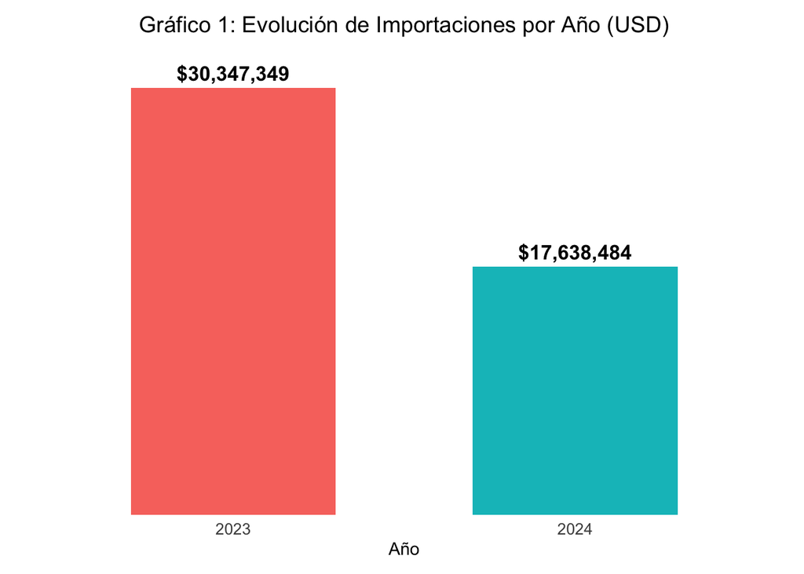

```r
#Gráfico
ggplot(datos_filtrados, aes(x = factor(Año), y = Total_Importaciones, fill = factor(Año))) +
  geom_bar(stat = "identity", show.legend = FALSE, width = 0.6) +
  geom_text(
    aes(label = scales::dollar(Total_Importaciones)),
    vjust = -0.5, size = 4.5, fontface = "bold", color = "black"
  ) +
  labs(
    title = "Gráfico 1: Evolución de Importaciones por Año (USD)",
    x = "Año",
    y = NULL
  ) +
  scale_y_continuous(expand = expansion(mult = c(0, 0.1))) +
  theme_minimal() +
  theme(
    plot.title = element_text(hjust = 0.5, size = 14, vjust = 1),
    axis.text.x = element_text(angle = 0, hjust = 0.5, size = 10),
    axis.text.y = element_blank(),  # Ocultar etiquetas en el eje Y
    plot.margin = margin(t = 10, r = 15, b = 10, l = 15),
    panel.grid.major = element_blank(),
    panel.grid.minor = element_blank(),
    panel.background = element_blank(),
    plot.background = element_blank()
  ) +
  coord_cartesian(clip = "off")  # Evitar recorte del texto
```

### Proyección anual

Se estima el comportamiento futuro de las importaciones basado en el promedio de los meses observados.

**Código**

```r
subset_mol <- subset_mol %>%
  mutate(Mes = as.numeric(Mes))

# Calcular ventas totales por mes y año
datos_por_mes <- subset_mol %>%
  group_by(Año, Mes) %>%
  summarise(
    Total_Importaciones = sum(`Valor FOB (USD)`, na.rm = TRUE)
  ) %>%
  mutate(
    Mes = factor(Mes, levels = 1:12, labels = c(
      "Enero", "Febrero", "Marzo", "Abril", "Mayo", "Junio", "Julio", "Agosto", "Septiembre", "Octubre", "Noviembre", "Diciembre"
    ))
  )

# Crear tabla de resumen con los resultados
tabla_por_mes <- datos_por_mes %>%
  mutate(Total_Importaciones = scales::dollar(Total_Importaciones)) %>%
  arrange(Año, Mes) %>%
  kable(
    format = "html",
    col.names = c("Año", "Mes", "Total Importaciones (USD)"),
    caption = "*Tabla: Importaciones Totales por Mes" #no se muestra
  ) %>%
  kable_styling(
    bootstrap_options = c("striped", "hover", "condensed", "responsive"),
    full_width = FALSE,
    position = "center"
  )
# Calcular ventas totales por año con proyección anual
datos_filtrados <- subset_mol %>%
  group_by(Año) %>%
  summarise(
    Meses_Disponibles = n_distinct(Mes),  # Meses únicos disponibles
    Total_Importaciones = sum(`Valor FOB (USD)`, na.rm = TRUE),
    Proyectado_Anual = if_else(
      Meses_Disponibles < 12 & Meses_Disponibles > 0,
      Total_Importaciones / Meses_Disponibles * 12,  # Calcular proyección
      Total_Importaciones  # Si hay 12 meses, no se proyecta
    )
  )

# Tabla de resumen con los resultados
tabla_resumen <- datos_filtrados %>%
  mutate(
    Total_Importaciones = scales::dollar(Total_Importaciones),
    Proyectado_Anual = scales::dollar(Proyectado_Anual)
  ) %>%
  kable(
    format = "html",
    col.names = c("Año", "Meses Disponibles", "Total Observado (USD)", "Proyectado Anual (USD)"),
    caption = "*Tabla 6: Importaciones Totales y Proyección Anual por Año"
  ) %>%
  kable_styling(
    bootstrap_options = c("striped", "hover", "condensed", "responsive"),
    full_width = FALSE,
    position = "center"
  )

# Mostrar tabla
tabla_resumen
```

*Tabla 6: Importaciones Totales y Proyección Anual por Año

| Año | Meses Disponibles | Total Observado (USD) | Proyectado Anual (USD) |
| --- | --- | --- | --- |
| 2023 | 12 | $30,347,349 | $30,347,349 |
| 2024 | 9 | $17,638,484 | $23,517,979 |

## Segmentación por tipo de producto

Se evalúa la evolución de cada tipo de producto en los años analizados, destacando variaciones en montos totales y participaciones relativas dentro del mercado.

**Código**

```r
tabla_tipo_producto_anual <- subset_mol %>%
  group_by(Año, Tipo_Producto) %>%
  summarise(Monto_Importado_Total = sum(`Valor FOB (USD)`, na.rm = TRUE), .groups = "drop") %>%
  group_by(Año) %>%
  mutate(Participacion = (Monto_Importado_Total / sum(Monto_Importado_Total, na.rm = TRUE)) * 100)

# Mostrar la tabla
tabla_tipo_producto_anual %>%
  arrange(Año, desc(Monto_Importado_Total)) %>%
  mutate(
    Monto_Importado_Total = scales::comma(Monto_Importado_Total, accuracy = 1),
    Participacion = paste0(format(round(Participacion, 2), nsmall = 2))
  ) %>%
  kable(
    format = "html",
    col.names = c("Año", "Categorías de Producto", "Monto Total Importado (USD)", "Participación (%)"),
    caption = "Tabla 7: Importaciones por Año y Tipo de Producto"
  ) %>%
  kable_styling(
    bootstrap_options = c("striped", "hover", "condensed", "responsive"),
    full_width = FALSE,
    position = "center"
  )
```

Tabla 7: Importaciones por Año y Tipo de Producto

| Año | Categorías de Producto | Monto Total Importado (USD) | Participación (%) |
| --- | --- | --- | --- |
| 2023 | REACTIVOS | 27,125,170 | 89.38 |
| 2023 | EQUIPOS | 2,903,478 | 9.57 |
| 2023 | OTROS | 318,701 | 1.05 |
| 2024 | REACTIVOS | 14,876,505 | 84.34 |
| 2024 | EQUIPOS | 2,615,956 | 14.83 |
| 2024 | OTROS | 146,023 | 0.83 |

**Código**

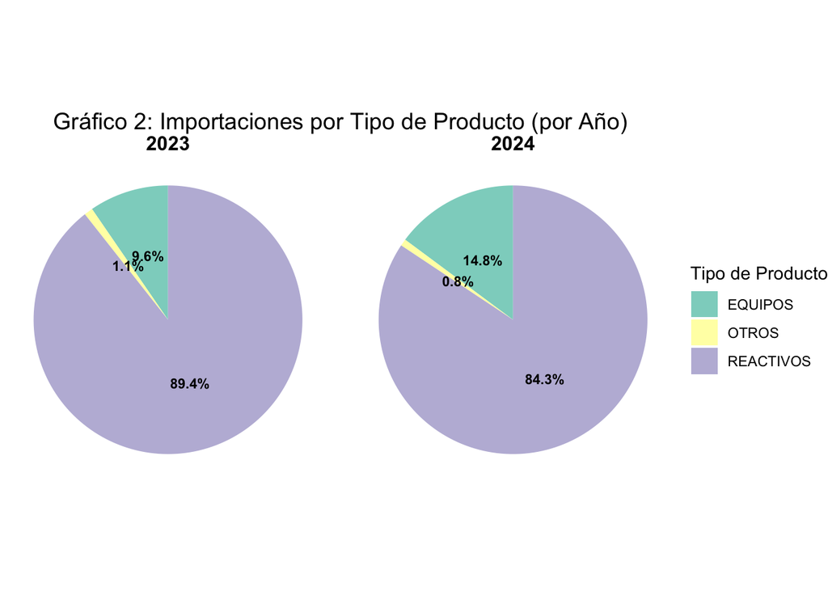

```r
# Crear gráficos de torta por cada año
ggplot(tabla_tipo_producto_anual, aes(x = "", y = Participacion, fill = Tipo_Producto)) +
  geom_bar(stat = "identity", width = 1) +
  coord_polar(theta = "y") +
  facet_wrap(~ Año) +  # Crear un gráfico por cada año
  geom_text(
    aes(label = paste0(round(Participacion, 1), "%")),
    position = position_stack(vjust = 0.5),
    size = 3,
    fontface = "bold"
  ) +
  labs(
    title = "Gráfico 2: Importaciones por Tipo de Producto (por Año)",
    x = NULL,
    y = NULL,
    fill = "Tipo de Producto"
  ) +
  scale_fill_brewer(palette = "Set3") +
  theme_void() +
  theme(
    plot.title = element_text(hjust = 0.5, size = 14),
    strip.text = element_text(size = 12, face = "bold")
  )
```

### Reactivos

Análisis del comportamiento del segmento de Reactivos.

**Código**

```r
# Calcular monto total por importador, tipo de producto y año
tabla_importador_producto_año <- subset_mol %>%
  group_by(Importador, Tipo_Producto, Año) %>%
  summarise(
    Monto_Importado = sum(`Valor FOB (USD)`, na.rm = TRUE),
    .groups = "drop"
  ) %>%
  distinct()

años_disponibles <- unique(tabla_importador_producto_año$Año)

# Reestructurar la tabla
tabla_importador_producto <- tabla_importador_producto_año %>%
  pivot_wider(
    names_from = Año,
    values_from = Monto_Importado,
    names_prefix = "Monto_"
  ) %>%
  mutate(
    Total_Importado = rowSums(across(starts_with("Monto_")), na.rm = TRUE)
  ) %>%
  arrange(desc(Total_Importado))

# Filtrar para obtener solo los datos de "REACTIVOS"
tabla_reactivos <- tabla_importador_producto %>%
  filter(Tipo_Producto == "REACTIVOS")

# Generar la tabla para Reactivos
tabla_reactivos %>%
  mutate(
    across(starts_with("Monto_"), ~scales::number(., big.mark = ",", decimal.mark = ".", accuracy = 1, scale = 1)),
    Total_Importado = scales::number(Total_Importado, big.mark = ",", decimal.mark = ".", accuracy = 1, scale = 1)
  ) %>%
  kable(
    format = "html",
    col.names = c("Importador", "Tipo de Producto", paste0("Monto ", años_disponibles, " (USD)"), "Total Importado (USD)"),
    caption = "Tabla 8: Importaciones de Reactivos por Importador y Año"
  ) %>%
  kable_styling(
    bootstrap_options = c("striped", "hover", "condensed", "responsive"),
    full_width = FALSE,
    position = "center"
  ) %>%
  scroll_box(width = "100%", height = "400px")
```

Tabla 8: Importaciones de Reactivos por Importador y Año

| Importador | Tipo de Producto | Monto 2024 (USD) | Monto 2023 (USD) | Total Importado (USD) |
| --- | --- | --- | --- | --- |
| MINISTERIO DE SALUD PUBLICA | REACTIVOS | 886,608 | 10,451,799 | 11,338,407 |
| ROCHE ECUADOR S.A. | REACTIVOS | 3,503,147 | 2,343,331 | 5,846,478 |
| PATRICIA NAVA GALEANO | REACTIVOS | 150,262 | 4,033,896 | 4,184,158 |
| SIMED S. A. | REACTIVOS | 1,150,935 | 946,710 | 2,097,645 |
| MERCK C.A. | REACTIVOS | 751,728 | 547,017 | 1,298,745 |
| RRPGOLDEN INTEGRA IMPORTADORA S.A. | REACTIVOS | NA | 1,047,407 | 1,047,407 |
| ABBOTT LABORATORIOS DEL ECUADOR CIA. LTDA. | REACTIVOS | 254,560 | 766,899 | 1,021,459 |
| DIMUNE S.A. | REACTIVOS | 336,012 | 515,277 | 851,289 |
| IMPVET IMPORTADORA VETERINARIA CIA. LTDA. | REACTIVOS | 386,897 | 463,026 | 849,923 |
| ROEMMERS S.A. | REACTIVOS | 603,693 | NA | 603,693 |
| PFIZER ANIMAL HEALTH CIA. LTDA. | REACTIVOS | 231,599 | 330,465 | 562,064 |
| GISIS S.A. | REACTIVOS | NA | 517,074 | 517,074 |
| AGROBIMSA S. A. | REACTIVOS | 181,276 | 232,333 | 413,608 |
| RESTREPO COMERCIAL INTERANDINA CIA. LTDA. | REACTIVOS | NA | 396,933 | 396,933 |
| AGRANTECH DEL ECUADOR AGRANTECUA S.A. | REACTIVOS | 394,192 | NA | 394,192 |
| FRISONEX FRISON IMPORTADORA EXPORTADORA CIA. LTDA. | REACTIVOS | 273,706 | 114,518 | 388,225 |
| BLUE HEALTH INTERNATIONAL ECUADOR S.A.S. | REACTIVOS | 292,832 | 90,867 | 383,700 |
| MEDILABOR S.A. | REACTIVOS | 153,225 | 220,989 | 374,214 |
| RAPIDIAGNOSTICS S.A. | REACTIVOS | 225,549 | 135,947 | 361,496 |
| DSM NUTRITIONAL PRODUCTS ECUADOR S.A. | REACTIVOS | 74,160 | 207,544 | 281,704 |
| VIBAG C.A. | REACTIVOS | 163,433 | 106,313 | 269,746 |
| EPICORE ECUADOR S.A. | REACTIVOS | 252,930 | NA | 252,930 |
| RALOECUADOR S.A. | REACTIVOS | 239,940 | NA | 239,940 |
| DISTRIBUIDORA DESCALZI S.A. | REACTIVOS | 132,882 | 106,403 | 239,285 |
| NIPRO MEDICAL CORPORATION | REACTIVOS | 152,810 | 72,831 | 225,641 |
| INVECUADOR S.A. | REACTIVOS | 105,522 | 107,720 | 213,242 |
| BOEHRINGER INGELHEIM DEL ECUADOR CIA. LTDA. | REACTIVOS | 108,853 | 103,158 | 212,011 |
| LAB QUALITY S.C.C. | REACTIVOS | 109,528 | 100,167 | 209,695 |
| PRIME LABORATORIO PRILAB S.A. | REACTIVOS | NA | 205,142 | 205,142 |
| ASESORIAS DE APOYO AL SECTOR ACUICOLA AQUAPRIME S A AQUAPRIME SOCIEDAD ANONIMA | REACTIVOS | 200,000 | NA | 200,000 |

[output cut: 273 more lines]

### Equipos

Evaluación del comportamiento del segmento de Equipos.

**Código**

```r
# Tabla de Equipos
tabla_equipos <- tabla_importador_producto %>%
  filter(Tipo_Producto == "EQUIPOS")

tabla_equipos %>%
  mutate(
    across(starts_with("Monto_"), ~scales::number(., big.mark = ",", decimal.mark = ".", accuracy = 1, scale = 1)),
    Total_Importado = scales::number(Total_Importado, big.mark = ",", decimal.mark = ".", accuracy = 1, scale = 1)  # Total sin decimales
  ) %>%
  kable(
    format = "html",
    col.names = c("Importador", "Tipo de Producto", paste0("Monto ", años_disponibles, " (USD)"), "Total Importado (USD)"),
    caption = "Tabla 9: Importaciones de Equipos por Importador y Año"
  ) %>%
  kable_styling(
    bootstrap_options = c("striped", "hover", "condensed", "responsive"),
    full_width = FALSE,
    position = "center"
  ) %>%
  scroll_box(width = "100%", height = "400px")
```

Tabla 9: Importaciones de Equipos por Importador y Año

| Importador | Tipo de Producto | Monto 2024 (USD) | Monto 2023 (USD) | Total Importado (USD) |
| --- | --- | --- | --- | --- |
| SIMED S. A. | EQUIPOS | 470,945 | 399,074 | 870,019 |
| ROCHE ECUADOR S.A. | EQUIPOS | 492,948 | 261,922 | 754,870 |
| VIBAG C.A. | EQUIPOS | 34,881 | 213,315 | 248,197 |
| REPRESENTACIONES PEDRO ARANEDA FERRER E HIJOS CIA. LTDA | EQUIPOS | NA | 200,400 | 200,400 |
| LAB QUALITY S.C.C. | EQUIPOS | 17,572 | 181,425 | 198,997 |
| RAPIDIAGNOSTICS S.A. | EQUIPOS | 175,419 | 17,790 | 193,209 |
| ESTRELLA SANGO JORGE ARTURO | EQUIPOS | 250 | 173,699 | 173,949 |
| FRISONEX FRISON IMPORTADORA EXPORTADORA CIA. LTDA. | EQUIPOS | 170,128 | 161 | 170,289 |
| DOLCA S.A. | EQUIPOS | 118,440 | 42,844 | 161,284 |
| MEDILABOR S.A. | EQUIPOS | 5,958 | 133,800 | 139,758 |
| PROVEEDORA DE INSTRUMENTOS ANALITICOS E INDUSTRIALES PROINSTRA S.A. | EQUIPOS | 20,436 | 77,468 | 97,905 |
| BLUE HEALTH INTERNATIONAL ECUADOR S.A.S. | EQUIPOS | 94,186 | 2,181 | 96,367 |
| ESTRELLA SANGO MIGUEL ANGEL | EQUIPOS | NA | 89,718 | 89,718 |
| BOSCHETTI S.A. | EQUIPOS | NA | 88,000 | 88,000 |
| JOSE JALIL & HIJOS REPRESENTACIONES Y COMERCIO CIA. LTDA. | EQUIPOS | 3,737 | 81,799 | 85,537 |
| IMPORTADORA DISTRIBUIDORA MAKOLECUADOR CIA. LTDA. | EQUIPOS | 76,070 | 8,753 | 84,823 |
| HALLIBURTON LATIN AMERICA S.A., LLC. | EQUIPOS | 73,648 | 2,833 | 76,481 |
| ELICROM CIA. LTDA | EQUIPOS | 41,400 | 24,065 | 65,465 |
| SUNIX TECH S.A.S. | EQUIPOS | NA | 61,649 | 61,649 |
| SISTEMAS DE SALUD ROCARSYSTEM S.A. | EQUIPOS | 34,617 | 26,814 | 61,431 |
| SCANALYTICAL CIA. LTDA. | EQUIPOS | 38,953 | 20,712 | 59,665 |
| PFIZER ANIMAL HEALTH CIA. LTDA. | EQUIPOS | 58,906 | NA | 58,906 |
| PURIFLUIDOS, PURIFICACION Y ANALISIS DE FLUIDOS CIA. LTDA. | EQUIPOS | 33,374 | 18,588 | 51,962 |
| CECUAMAQ, CORPORACION ECUATORIANA INDUSTRIAL DE MAQUINARIA C.A. | EQUIPOS | NA | 49,704 | 49,704 |
| CALEB BRETT ECUADOR S.A. | EQUIPOS | NA | 40,150 | 40,150 |
| FARMAYALA PHARMACEUTICAL COMPANY S.A. FPC | EQUIPOS | 7,108 | 32,807 | 39,915 |
| MACROQUIL S.A. | EQUIPOS | 1,800 | 37,182 | 38,982 |
| HDM ELQUITECNICA CIA. LTDA. | EQUIPOS | NA | 38,304 | 38,304 |
| PEREIRA VIVANCO FREDY JOEL | EQUIPOS | 1,247 | 30,022 | 31,269 |
| IMPORTADORA INDUSTRIAL AGRICOLA S.A. I.I.A.S.A. | EQUIPOS | 30,650 | NA | 30,650 |

[output cut: 259 more lines]

**Nota**

*El segmento de “OTROS” no será analizado, ya que su participación en el mercado es mínima y no tiene un impacto relevante en los resultados del análisis.*

## Importadores

El análisis se enfocará en el comportamiento global de los importadores, evaluando su participación en el mercado, las variaciones en las cantidades importadas y cómo estas dinámicas evolucionan a lo largo de los años.

### Total de Importadores

Se incluirán todos los años del conjunto de datos para calcular el total de importadores, sin realizar segmentaciones por períodos específicos.

**Código**

```r
# Asegurarse de que la columna Importador es de tipo carácter
subset_mol <- subset_mol %>%
  mutate(Importador = as.character(Importador))

# Calcular el total de ventas
total_ventas <- sum(dataset_mol$`Valor FOB (USD)`, na.rm = TRUE)

# Crear la tabla de resumen por importador
tabla_importadores <- dataset_mol %>%
  group_by(Importador) %>%
  summarise(
    Monto_Importado_Total = sum(`Valor FOB (USD)`, na.rm = TRUE)
  ) %>%
  arrange(desc(Monto_Importado_Total)) %>%
  mutate(
    Participacion = (Monto_Importado_Total / total_ventas) * 100,
    Monto_Importado_Total = scales::dollar(Monto_Importado_Total),
    Participacion = round(Participacion, 2)
  )

# Tabla
tabla_importadores %>%
  kable(
    format = "html",
    col.names = c("Importador", "Monto Total Importado (USD)", "Participación (%)"),
    caption = "Tabla 10: Informe por Importador"
  ) %>%
  kable_styling(
    bootstrap_options = c("striped", "hover", "condensed", "responsive"),
    full_width = FALSE,
    position = "center"
  ) %>%
  scroll_box(width = "100%", height = "400px")
```

Tabla 10: Informe por Importador

| Importador | Monto Total Importado (USD) | Participación (%) |
| --- | --- | --- |
| MINISTERIO DE SALUD PUBLICA | $11,338,407 | 23.63 |
| ROCHE ECUADOR S.A. | $6,601,347 | 13.76 |
| PATRICIA NAVA GALEANO | $4,184,158 | 8.72 |
| SIMED S. A. | $2,967,664 | 6.18 |
| MERCK C.A. | $1,298,745 | 2.71 |
| RRPGOLDEN INTEGRA IMPORTADORA S.A. | $1,047,407 | 2.18 |
| ABBOTT LABORATORIOS DEL ECUADOR CIA. LTDA. | $1,021,459 | 2.13 |
| DIMUNE S.A. | $851,289 | 1.77 |
| IMPVET IMPORTADORA VETERINARIA CIA. LTDA. | $849,923 | 1.77 |
| PFIZER ANIMAL HEALTH CIA. LTDA. | $620,970 | 1.29 |
| ROEMMERS S.A. | $603,693 | 1.26 |
| FRISONEX FRISON IMPORTADORA EXPORTADORA CIA. LTDA. | $558,514 | 1.16 |
| RAPIDIAGNOSTICS S.A. | $554,705 | 1.16 |
| GISIS S.A. | $520,118 | 1.08 |
| VIBAG C.A. | $517,943 | 1.08 |
| MEDILABOR S.A. | $513,972 | 1.07 |
| BLUE HEALTH INTERNATIONAL ECUADOR S.A.S. | $480,066 | 1.00 |
| AGROBIMSA S. A. | $413,608 | 0.86 |
| LAB QUALITY S.C.C. | $408,692 | 0.85 |
| RESTREPO COMERCIAL INTERANDINA CIA. LTDA. | $396,933 | 0.83 |
| AGRANTECH DEL ECUADOR AGRANTECUA S.A. | $394,192 | 0.82 |
| DOLCA S.A. | $298,518 | 0.62 |
| DSM NUTRITIONAL PRODUCTS ECUADOR S.A. | $281,704 | 0.59 |
| EPICORE ECUADOR S.A. | $252,930 | 0.53 |
| REPRESENTACIONES PEDRO ARANEDA FERRER E HIJOS CIA. LTDA | $251,680 | 0.52 |
| RALOECUADOR S.A. | $239,940 | 0.50 |
| DISTRIBUIDORA DESCALZI S.A. | $239,285 | 0.50 |
| ESTRELLA SANGO JORGE ARTURO | $237,975 | 0.50 |
| NIPRO MEDICAL CORPORATION | $232,046 | 0.48 |
| SISTEMAS DE SALUD ROCARSYSTEM S.A. | $229,353 | 0.48 |

[output cut: 560 more lines]

### Importaciones por Año

Se presentará los datos de evolución de las importaciones de los 10 principales importadores por cada año analizado.

**Código**

```r
# Calcular el total de ventas por año
total_ventas_por_año <- subset_mol %>%
  group_by(Año) %>%
  summarise(
    Total_Ventas_Año = sum(`Valor FOB (USD)`, na.rm = TRUE)
  )

tabla_importador_año <- subset_mol %>%
  group_by(Año, Importador) %>%
  summarise(
    Monto_Importado_Total = sum(`Valor FOB (USD)`, na.rm = TRUE)
  ) %>%
  left_join(total_ventas_por_año, by = "Año") %>%
  mutate(
    Participacion = (Monto_Importado_Total / Total_Ventas_Año) * 100
  ) %>%
  arrange(Año, Importador, desc(Monto_Importado_Total))

# Obtener los 10 principales importadores
tabla_top10_importadores <- tabla_importador_año %>%
  slice_max(order_by = Monto_Importado_Total, n = 10)

# Tabla
tabla_top10_importadores %>%
  select(Año, Importador, Monto_Importado_Total, Participacion) %>%
  mutate(
    Monto_Importado_Total = number(Monto_Importado_Total, big.mark = ",", accuracy = 0.01),
    Participacion = round(Participacion, 2)
  ) %>%
  kable(
    format = "html",
    col.names = c("Año", "Importador", "Monto Importado Total (USD)", "Participación (%)"),
    caption = "Tabla 11: Top 10 Importadores por Año"
  ) %>%
  kable_styling(
    bootstrap_options = c("striped", "hover", "condensed", "responsive"),
    full_width = FALSE,
    position = "center"
  ) %>%
  scroll_box(width = "100%", height = "400px")
```

Tabla 11: Top 10 Importadores por Año

| Año | Importador | Monto Importado Total (USD) | Participación (%) |
| --- | --- | --- | --- |
| 2023 | MINISTERIO DE SALUD PUBLICA | 10,451,799.00 | 34.44 |
| 2023 | PATRICIA NAVA GALEANO | 4,033,896.00 | 13.29 |
| 2023 | ROCHE ECUADOR S.A. | 2,605,252.06 | 8.58 |
| 2023 | SIMED S. A. | 1,345,783.60 | 4.43 |
| 2023 | RRPGOLDEN INTEGRA IMPORTADORA S.A. | 1,047,407.00 | 3.45 |
| 2023 | ABBOTT LABORATORIOS DEL ECUADOR CIA. LTDA. | 766,899.00 | 2.53 |
| 2023 | MERCK C.A. | 547,016.94 | 1.80 |
| 2023 | GISIS S.A. | 520,117.56 | 1.71 |
| 2023 | DIMUNE S.A. | 515,277.00 | 1.70 |
| 2023 | IMPVET IMPORTADORA VETERINARIA CIA. LTDA. | 463,026.01 | 1.53 |
| 2024 | ROCHE ECUADOR S.A. | 3,996,095.14 | 22.66 |
| 2024 | SIMED S. A. | 1,621,880.54 | 9.20 |
| 2024 | MINISTERIO DE SALUD PUBLICA | 886,608.00 | 5.03 |
| 2024 | MERCK C.A. | 751,727.75 | 4.26 |
| 2024 | ROEMMERS S.A. | 603,693.46 | 3.42 |
| 2024 | FRISONEX FRISON IMPORTADORA EXPORTADORA CIA. LTDA. | 443,834.65 | 2.52 |
| 2024 | RAPIDIAGNOSTICS S.A. | 400,968.21 | 2.27 |
| 2024 | AGRANTECH DEL ECUADOR AGRANTECUA S.A. | 394,192.00 | 2.23 |
| 2024 | BLUE HEALTH INTERNATIONAL ECUADOR S.A.S. | 387,018.33 | 2.19 |
| 2024 | IMPVET IMPORTADORA VETERINARIA CIA. LTDA. | 386,897.10 | 2.19 |

## Competidores directos

Se proporcionará un análisis detallado de las empresas que comercializan los mismos equipos que `Wiener Lab`, identificando a aquellos competidores que operan en el mismo segmento de mercado.

**Código**

```r
# Filtrar los datos por la marca "MINDRAY" y agrupar por importador
tabla_importadores_mindray <- subset_mol %>%
  filter(Marca == "MINDRAY") %>%
  group_by(Importador) %>%
  summarise(
    Monto_Importado_Total = sum(`Valor FOB (USD)`, na.rm = TRUE),
    .groups = "drop"
  ) %>%
  mutate(
    Participacion = (Monto_Importado_Total / sum(Monto_Importado_Total)) * 100,
    Monto_Importado_Total = scales::comma(Monto_Importado_Total, accuracy = 1),
    Participacion = scales::percent(Participacion / 100, accuracy = 0.01)
  ) %>%
  arrange(desc(Participacion))

# Tabla
tabla_importadores_mindray %>%
  kable(
    format = "html",
    col.names = c("Importadores", "Total Importado (USD)", "Participación (%)"),
    caption = "*Tabla 12: Importadores de la Marca 'MINDRAY'*"
  ) %>%
  kable_styling(
    bootstrap_options = c("striped", "hover", "condensed", "responsive"),
    full_width = FALSE,
    position = "center"
  )
```

*Tabla 12: Importadores de la Marca 'MINDRAY'*

| Importadores | Total Importado (USD) | Participación (%) |
| --- | --- | --- |
| SIMED S. A. | 506,985 | 57.51% |
| MEDILABOR S.A. | 374,554 | 42.49% |

## Presencia en el mercado

**Código**

```r
# Filtrar los datos por la marca "WIENER" y agrupar por importador
tabla_importadores_mindray <- subset_mol %>%
  filter(Marca == "WIENER") %>%  # Filtrar por Marca
  group_by(Importador) %>%
  summarise(
    Monto_Importado_Total = sum(`Valor FOB (USD)`, na.rm = TRUE)  # Sumar el monto FOB
  ) %>%
  ungroup() %>%
  mutate(
    Participacion = (Monto_Importado_Total / sum(Monto_Importado_Total)) * 100,
    Monto_Importado_Total = comma(Monto_Importado_Total, accuracy = 0.01),
    Participacion = percent(Participacion / 100, accuracy = 0.01)
  ) %>%
  arrange(desc(Monto_Importado_Total))

# Table
tabla_importadores_mindray %>%
  kable(
    format = "html",
    col.names = c("Importador", "Monto Total Importado (USD)", "Participación (%)"),
    caption = "*Tabla 13: Importadores de la Marca 'WIENER LAB'*"
  ) %>%
  kable_styling(
    bootstrap_options = c("striped", "hover", "condensed", "responsive"),
    full_width = FALSE,
    position = "center"
  )
```

*Tabla 13: Importadores de la Marca 'WIENER LAB'*

| Importador | Monto Total Importado (USD) | Participación (%) |
| --- | --- | --- |
| RECOR DENTAL Y QUIMEDIC CIA. LTDA. | 13,025.00 | 100.00% |

**Nota**

*Este informe ha sido creado con el objetivo de estandarizar el análisis inicial de importaciones. Dado que se trata de una fase preliminar, no se incluyen conclusiones en este documento, ya que su propósito es ofrecer una visión global y consolidada que sirva como base para los análisis Ad hoc subsecuentes.*